# hw2

Liming Ning, Xinran Zhang

2022/2/13

# 1 Case Study 1: Self esteem

## 1.1 Data preparation

```r
esteem = fread("data/NLSY79.csv")
skim(esteem)
```

Data summary

| Name | esteem |
| --- | --- |
| Number of rows | 2431 |
| Number of columns | 46 |
| Key | NULL |
| _______________________ |  |
| Column type frequency: |  |
| character | 2 |
| numeric | 44 |
| ________________________ |  |
| Group variables | None |

**Variable type: character**

| skim_variable | n_missing | complete_rate | min | max | empty | n_unique | whitespace |
| --- | --- | --- | --- | --- | --- | --- | --- |
| Gender | 0 | 1 | 4 | 6 | 0 | 2 | 0 |
| Job05 | 0 | 1 | 0 | 83 | 56 | 31 | 0 |

**Variable type: numeric**

| skim_variable | n_missing | complete_rate | mean | sd | p0 | p25 | p50 | p75 | p100 | hist |
| --- | --- | --- | --- | --- | --- | --- | --- | --- | --- | --- |
| Subject | 0 | 1 | 3504.50 | 2764.82 | 2 | 1592.5 | 3137 | 4668.5 | 12140 | ▇▇▃▁▂ |
| Education05 | 0 | 1 | 13.91 | 2.50 | 6 | 12.0 | 13 | 16.0 | 20 | ▁▁▇▃▂ |
| Income87 | 0 | 1 | 13398.80 | 11599.62 | -2 | 4500.0 | 12000 | 19000.0 | 59387 | ▇▆▂▁▁ |
| Income05 | 0 | 1 | 49414.80 | 46287.60 | 63 | 22650.0 | 38500 | 61350.0 | 703637 | ▇▁▁▁▁ |
| Weight05 | 0 | 1 | 183.10 | 41.71 | 81 | 150.0 | 180 | 209.0 | 380 | ▂▇▃▁▁ |
| HeightFeet05 | 0 | 1 | 5.18 | 0.57 | -4 | 5.0 | 5 | 5.0 | 8 | ▁▁▁▇▂ |
| HeightInch05 | 0 | 1 | 5.32 | 3.51 | 0 | 2.0 | 5 | 8.0 | 11 | ▇▅▅▅▇ |
| Imagazine | 0 | 1 | 0.72 | 0.45 | 0 | 0.0 | 1 | 1.0 | 1 | ▃▁▁▁▇ |
| Inewspaper | 0 | 1 | 0.86 | 0.35 | 0 | 1.0 | 1 | 1.0 | 1 | ▁▁▁▁▇ |
| Ilibrary | 0 | 1 | 0.77 | 0.42 | 0 | 1.0 | 1 | 1.0 | 1 | ▂▁▁▁▇ |
| MotherEd | 0 | 1 | 11.70 | 2.61 | 0 | 11.0 | 12 | 12.0 | 20 | ▁▁▇▂▁ |
| FatherEd | 0 | 1 | 11.85 | 3.56 | 0 | 10.0 | 12 | 14.0 | 20 | ▁▂▇▃▁ |
| FamilyIncome78 | 0 | 1 | 21251.67 | 13878.56 | 0 | 11167.0 | 20000 | 27500.0 | 75001 | ▇▇▂▁▁ |
| Science | 0 | 1 | 16.29 | 4.77 | 0 | 13.0 | 17 | 20.0 | 25 | ▁▂▆▇▅ |
| Arith | 0 | 1 | 18.59 | 7.15 | 0 | 13.0 | 19 | 25.0 | 30 | ▁▆▇▇▇ |
| Word | 0 | 1 | 26.61 | 7.02 | 0 | 23.0 | 28 | 32.0 | 35 | ▁▁▂▅▇ |
| Parag | 0 | 1 | 11.23 | 3.15 | 0 | 10.0 | 12 | 14.0 | 15 | ▁▂▂▆▇ |
| Number | 0 | 1 | 35.46 | 10.11 | 0 | 29.0 | 36 | 44.0 | 50 | ▁▂▅▇▇ |
| Coding | 0 | 1 | 47.05 | 15.24 | 0 | 38.0 | 48 | 57.0 | 84 | ▁▃▇▇▂ |
| Auto | 0 | 1 | 14.26 | 5.32 | 0 | 10.0 | 14 | 18.0 | 25 | ▁▆▇▆▅ |
| Math | 0 | 1 | 14.26 | 6.29 | 0 | 9.0 | 14 | 20.0 | 25 | ▂▇▇▆▇ |
| Mechanic | 0 | 1 | 14.43 | 5.10 | 0 | 11.0 | 14 | 18.0 | 25 | ▁▅▇▆▃ |
| Elec | 0 | 1 | 11.59 | 4.09 | 0 | 9.0 | 12 | 15.0 | 20 | ▁▅▇▇▃ |
| AFQT | 0 | 1 | 54.68 | 27.70 | 0 | 31.9 | 57 | 78.2 | 100 | ▅▆▇▇▇ |
| Esteem81_1 | 0 | 1 | 1.42 | 0.52 | 1 | 1.0 | 1 | 2.0 | 4 | ▇▆▁▁▁ |
| Esteem81_2 | 0 | 1 | 1.42 | 0.51 | 1 | 1.0 | 1 | 2.0 | 4 | ▇▆▁▁▁ |
| Esteem81_3 | 0 | 1 | 3.51 | 0.57 | 1 | 3.0 | 4 | 4.0 | 4 | ▁▁▁▆▇ |
| Esteem81_4 | 0 | 1 | 1.57 | 0.56 | 1 | 1.0 | 2 | 2.0 | 4 | ▇▇▁▁▁ |
| Esteem81_5 | 0 | 1 | 3.46 | 0.65 | 1 | 3.0 | 4 | 4.0 | 4 | ▁▁▁▆▇ |
| Esteem81_6 | 0 | 1 | 1.62 | 0.56 | 1 | 1.0 | 2 | 2.0 | 4 | ▆▇▁▁▁ |
| Esteem81_7 | 0 | 1 | 1.75 | 0.60 | 1 | 1.0 | 2 | 2.0 | 4 | ▅▇▁▁▁ |
| Esteem81_8 | 0 | 1 | 3.13 | 0.76 | 1 | 3.0 | 3 | 4.0 | 4 | ▁▂▁▇▆ |
| Esteem81_9 | 0 | 1 | 3.16 | 0.72 | 1 | 3.0 | 3 | 4.0 | 4 | ▁▂▁▇▆ |
| Esteem81_10 | 0 | 1 | 3.40 | 0.66 | 1 | 3.0 | 3 | 4.0 | 4 | ▁▁▁▇▇ |
| Esteem87_1 | 0 | 1 | 1.38 | 0.50 | 1 | 1.0 | 1 | 2.0 | 4 | ▇▅▁▁▁ |
| Esteem87_2 | 0 | 1 | 1.40 | 0.50 | 1 | 1.0 | 1 | 2.0 | 4 | ▇▅▁▁▁ |
| Esteem87_3 | 0 | 1 | 3.58 | 0.54 | 1 | 3.0 | 4 | 4.0 | 4 | ▁▁▁▅▇ |
| Esteem87_4 | 0 | 1 | 1.50 | 0.53 | 1 | 1.0 | 1 | 2.0 | 4 | ▇▇▁▁▁ |
| Esteem87_5 | 0 | 1 | 3.53 | 0.60 | 1 | 3.0 | 4 | 4.0 | 4 | ▁▁▁▆▇ |
| Esteem87_6 | 0 | 1 | 1.59 | 0.56 | 1 | 1.0 | 2 | 2.0 | 4 | ▆▇▁▁▁ |
| Esteem87_7 | 0 | 1 | 1.72 | 0.58 | 1 | 1.0 | 2 | 2.0 | 4 | ▅▇▁▁▁ |
| Esteem87_8 | 0 | 1 | 3.10 | 0.74 | 1 | 3.0 | 3 | 4.0 | 4 | ▁▃▁▇▅ |
| Esteem87_9 | 0 | 1 | 3.06 | 0.74 | 1 | 3.0 | 3 | 4.0 | 4 | ▁▃▁▇▅ |
| Esteem87_10 | 0 | 1 | 3.37 | 0.65 | 1 | 3.0 | 3 | 4.0 | 4 | ▁▁▁▇▇ |

```r
esteem.isnull = data.frame(matrix(nrow = nrow(esteem),ncol = ncol(esteem)))
for (i in 1:ncol(esteem)) {
  esteem.isnull[i] = sapply(esteem[,eval(parse(text = i))], is.null)
}
colnames(esteem.isnull) = colnames(esteem)
apply(esteem.isnull,2,sum)
```

```
##        Subject         Gender    Education05       Income87          Job05
##              0              0              0              0              0
##       Income05       Weight05   HeightFeet05   HeightInch05      Imagazine
##              0              0              0              0              0
##     Inewspaper       Ilibrary       MotherEd       FatherEd FamilyIncome78
##              0              0              0              0              0
##        Science          Arith           Word          Parag         Number
##              0              0              0              0              0
##         Coding           Auto           Math       Mechanic           Elec
##              0              0              0              0              0
##           AFQT     Esteem81_1     Esteem81_2     Esteem81_3     Esteem81_4
##              0              0              0              0              0
##     Esteem81_5     Esteem81_6     Esteem81_7     Esteem81_8     Esteem81_9
##              0              0              0              0              0
##    Esteem81_10     Esteem87_1     Esteem87_2     Esteem87_3     Esteem87_4
##              0              0              0              0              0
##     Esteem87_5     Esteem87_6     Esteem87_7     Esteem87_8     Esteem87_9
##              0              0              0              0              0
##    Esteem87_10
##              0
```

No Null in the data set.

```r
apply(esteem == "", 2, sum)
```

```
##        Subject         Gender    Education05       Income87          Job05
##              0              0              0              0             56
##       Income05       Weight05   HeightFeet05   HeightInch05      Imagazine
##              0              0              0              0              0
##     Inewspaper       Ilibrary       MotherEd       FatherEd FamilyIncome78
##              0              0              0              0              0
##        Science          Arith           Word          Parag         Number
##              0              0              0              0              0
##         Coding           Auto           Math       Mechanic           Elec
##              0              0              0              0              0
##           AFQT     Esteem81_1     Esteem81_2     Esteem81_3     Esteem81_4
##              0              0              0              0              0
##     Esteem81_5     Esteem81_6     Esteem81_7     Esteem81_8     Esteem81_9
##              0              0              0              0              0
##    Esteem81_10     Esteem87_1     Esteem87_2     Esteem87_3     Esteem87_4
##              0              0              0              0              0
##     Esteem87_5     Esteem87_6     Esteem87_7     Esteem87_8     Esteem87_9
##              0              0              0              0              0
##    Esteem87_10
##              0
```

56 subjects do not have Job05 information. We decide to exclude them.

```r
esteem = esteem[Income87>=0&HeightFeet05>0&Job05 != ""]
```

The data is well cleaned. There is no missing value in the data set. It is worth noting that some subjects in the data have negative income (Income87) and negative height (HeightFeet05), which by common sense are susceptible. These numbers are erroneous and should be excluded. 30 subjects are excluded, relative small compared to the total number of subjects.

## 1.2 Self esteem evaluation

### 1.2.1 Reversion

```r
# for (i in c(81,87)) {
#   for (j in c(1,2,4,6,7)) {
#     esteem = esteem %>%
#   mutate_at(vars(paste0("Esteem",i,"_",j)), ~5-.)
#   }
# }

for (i in c(81,87)) {
  for (j in c(1,2,4,6,7)) {
    esteem[,paste0("Esteem",i,"_",j) := 5-get(paste0("Esteem",i,"_",j))]
  }
}
```

### 1.2.2 Brief summary for the esteem measurements

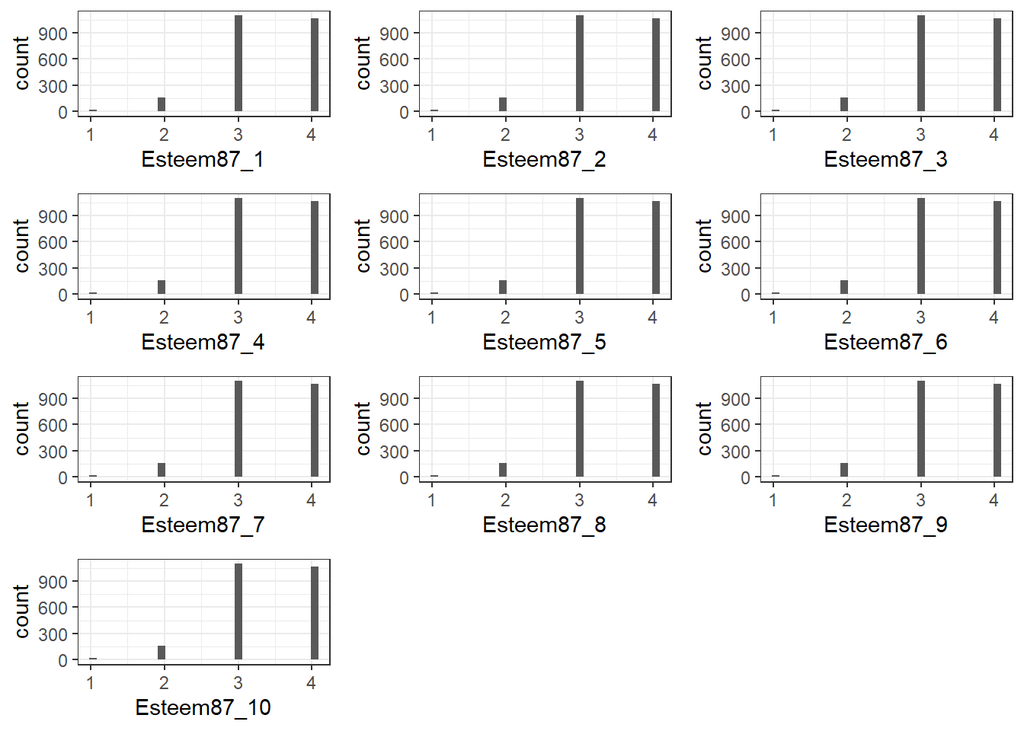

```r
plot.esteem = list()
for (i in 1:10) {
  plot.esteem[[i]] = ggplot(data = esteem)+
    geom_histogram(aes(x=get(paste0("Esteem",87,"_",i))))+
    xlab(paste0("Esteem",87,"_",i))+
    theme_bw()
}

plot_grid(plotlist = plot.esteem,nrow = 4)
```

There are ten different dimensions in the evaluation of self esteem in 1987, including the perception of self ability, self value, attitude and so on. These questions can capture most of the components for self esteem. The answer to every question ranges from 1 to 4, where a larger number means a better manifestation of self esteem in this aspect. From the histogram we can see that most subjects score 3 or 4 in each question, indicating that most people have a strong self esteem. The distribution of scores is almost the same across questions, implying a positive correlation between the scores.

### 1.2.3 Correlation between measurements of self esteem

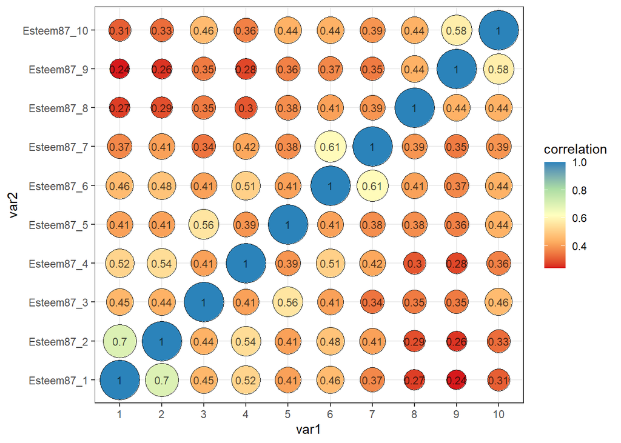

```r
corr.mat = data.frame(round(cor(esteem[,Esteem87_1:Esteem87_10]), digits = 2),var1 = names(esteem)[37:46])
corr.mat$var1 = 1:10
corr.mat.long = melt(corr.mat,id.vars = "var1", variable.name = "var2", value.name = "correlation")

my_color = brewer.pal(5, "Spectral")
ggplot(data = corr.mat.long,aes(x=as.factor(var1),y=var2,fill = correlation))+
  geom_point(aes(size = abs(correlation)), shape = 21) +
  geom_text(aes(label = correlation), size = 3, colour = "black", alpha = 0.7)+
  scale_fill_gradientn(colours = my_color) +
  xlab("var1")+
  scale_size_area(max_size = 15, guide = "none") +
  theme_bw()
```

From the correlation matrix, we can see that all ten measures of self esteem are positively correlated more or less. This is reasonable since they are all measuring self esteem and a larger nuber indicates a stronger self esteem for all of them. Despite that, their correlation is not extremely high, implying that they are effectively measuring different aspects of self esteem.

### 1.2.4 PCA

**The first two PCs**

```r
pca.esteem = prcomp(esteem[,Esteem87_1:Esteem87_10], center = T)
pc.firsttwo = pca.esteem$rotation[,1:2] # the first two PCs
kbl(pc.firsttwo, caption = "Loadings for PC1 and PC2", digits = 2, booktabs = T,
    align = "lcc") %>%
  kable_styling(latex_options = c("HOLD_position"))
```

Loadings for PC1 and PC2

|  | PC1 | PC2 |
| --- | --- | --- |
| Esteem87_1 | 0.23 | -0.37 |
| Esteem87_2 | 0.24 | -0.36 |
| Esteem87_3 | 0.28 | -0.16 |
| Esteem87_4 | 0.26 | -0.32 |
| Esteem87_5 | 0.31 | -0.14 |
| Esteem87_6 | 0.31 | -0.21 |
| Esteem87_7 | 0.30 | -0.16 |
| Esteem87_8 | 0.39 | 0.33 |
| Esteem87_9 | 0.40 | 0.58 |
| Esteem87_10 | 0.38 | 0.26 |

```r
round(t(pc.firsttwo) %*% pc.firsttwo, digits = 3)
```

```
##     PC1 PC2
## PC1   1   0
## PC2   0   1
```

The result shows that both PCs are unit vector. They are orthogonal, judging from the fact that their inner product is zero (ignoring the rounding errors when the computer converts a decimal number into a binary number).

**Interpretations for the first two PCs**

The first PC is essentially almost the average of all measures, evaluating the overall self esteem revealed by all questions. The second PC seems to represent the difference between question 8, 9, 10 and question 1, 2, 4. The former are all negative description of self esteem while the latter are all positive description of self esteem. Thus PC2 can be interpreted as measuring the inconsistency when people evaluate themselves facing essentially the same but only literally opposite expressions.

**Formula for calculating PC scores**

Denote the original response vector for a subject $i$ as $y_i$, and the loading for $PC_j$ is $l_j$.

Subject $i$’s $PC_j$ score:
$$y'_j = <y_i,l_j> = y^T_i l_j.$$

**Correlation between PC1 and PC2**

```r
round(cor(pca.esteem$x[,1:2]),digits = 3)
```

```
##     PC1 PC2
## PC1   1   0
## PC2   0   1
```

PC1 scores and PC2 scores are uncorrelated (ignoring the rounding errors when the computer converts a decimal number into a binary number).

**PVE**

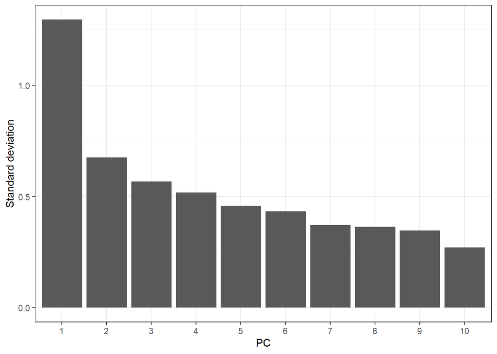

```r
pve.esteem = data.table(t(summary(pca.esteem)$importance))
pve.esteem[, PC := as.factor(1:10)]
ggplot(pve.esteem,aes(x=PC,weight = `Standard deviation`))+
  geom_bar()+
  ylab("Standard deviation")+
  theme_bw()
```

The explanatory power of PCs drops sharply from PC2 on. The first PC accounts for significantly more variance than others, and the explanatory power of other PCs is quite close.

**CPVE**

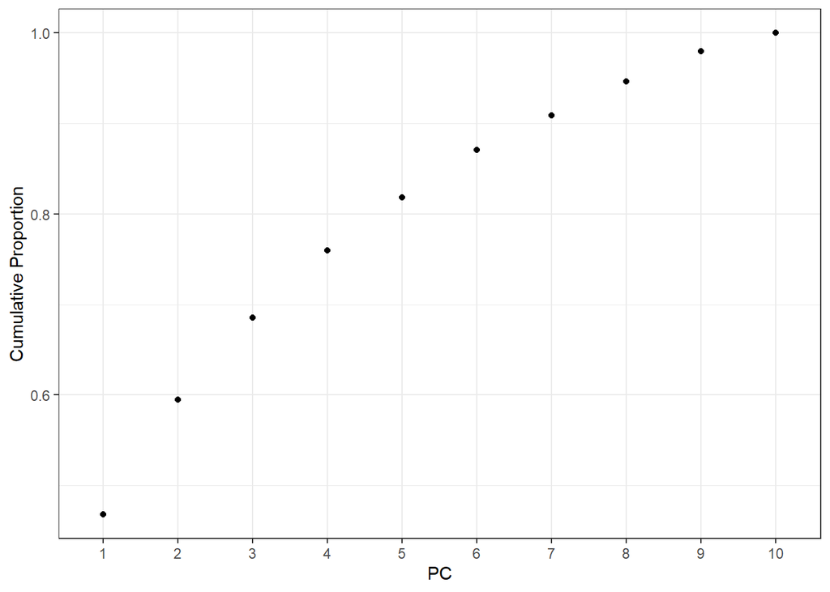

```r
ggplot(pve.esteem,aes(x=PC,y = `Cumulative Proportion`))+
  geom_point()+
  ylab("Cumulative Proportion")+
  theme_bw()
```

60% of the variance is explained by the first two PCs.

**Biplot**

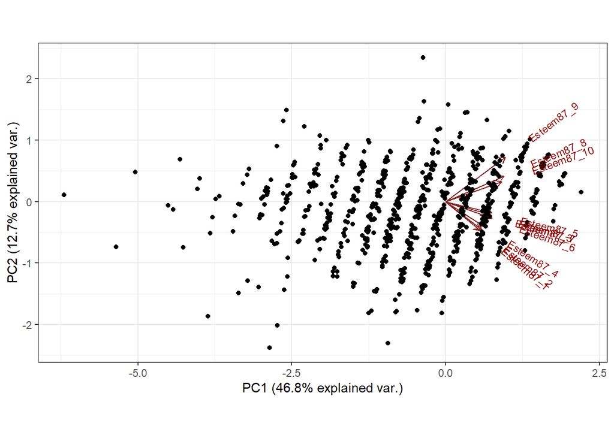

```r
ggbiplot(pca.esteem,obs.scale = 1.5, var.scale = 1, varname.adjust = 2,varname.size = 3)+
  theme_bw()
```

Interpretation for PC1: the average of all questions.

Interpretation for PC2: the difference between question 8, 9, 10 and the rest. ### Clustering

**Determine number of clusters**

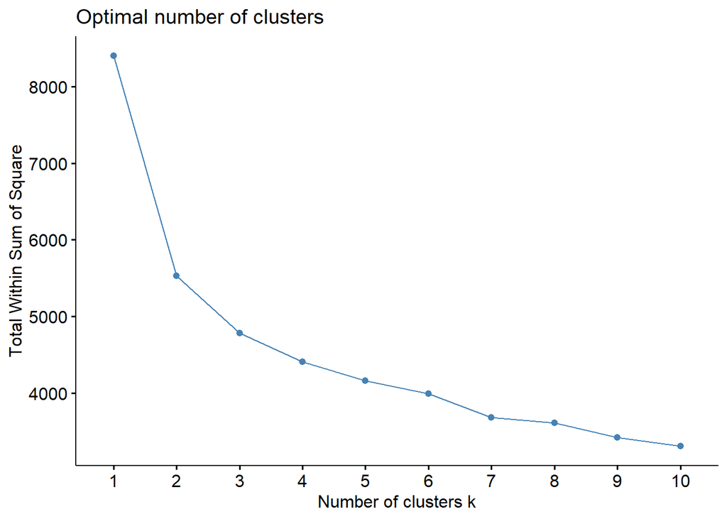

```r
fviz_nbclust(esteem[,Esteem87_1:Esteem87_10], kmeans, method = "wss")
```

We choose the number of clusters to be 2.

**Cluster features**

By prior knowledge, we speculate that the two clusters are for strong self esteem group and weak self esteem group. If this is the case, the common feature should be: one group features relatively high scores in every question while the other group features relatively low scores in every question.

```r
set.seed(1)
esteem.cluster2.origin = kmeans(esteem[,Esteem87_1:Esteem87_10], centers = 2)
esteem.cluster2.origin.center = t(esteem.cluster2.origin$centers)
colnames(esteem.cluster2.origin.center) = c("cluster1","cluster2")

kbl(esteem.cluster2.origin.center, caption = "Centers for Two Clusters", digits = 2, booktabs = T,
    align = "lcc") %>%
  kable_styling(latex_options = c("HOLD_position"))
```

Centers for Two Clusters

|  | cluster1 | cluster2 |
| --- | --- | --- |
| Esteem87_1 | 3.37 | 3.89 |
| Esteem87_2 | 3.33 | 3.89 |
| Esteem87_3 | 3.29 | 3.90 |
| Esteem87_4 | 3.20 | 3.82 |
| Esteem87_5 | 3.19 | 3.90 |
| Esteem87_6 | 3.07 | 3.78 |
| Esteem87_7 | 2.96 | 3.63 |
| Esteem87_8 | 2.70 | 3.54 |
| Esteem87_9 | 2.67 | 3.49 |
| Esteem87_10 | 2.96 | 3.80 |

**Visualization**

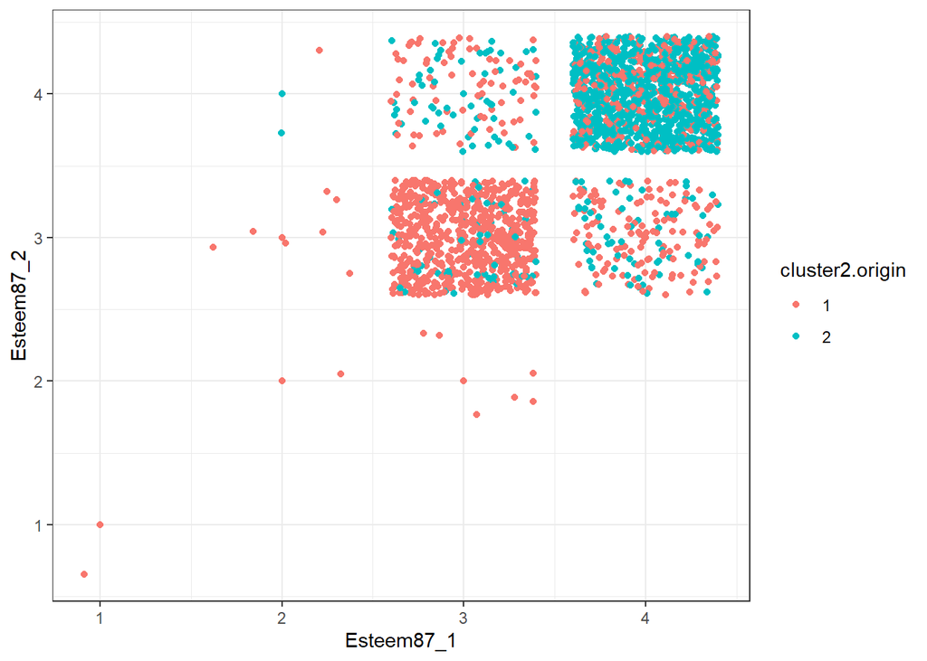

```r
esteem[,cluster2.origin := as.factor(esteem.cluster2.origin$cluster)]

ggplot(data = esteem, aes(x=Esteem87_1,y=Esteem87_2,group = cluster2.origin,color=cluster2.origin))+
  geom_point()+
  geom_jitter()+
  theme_bw()
```

The boundary of two clusters is not very clear in the scatter plot of two original measurements.

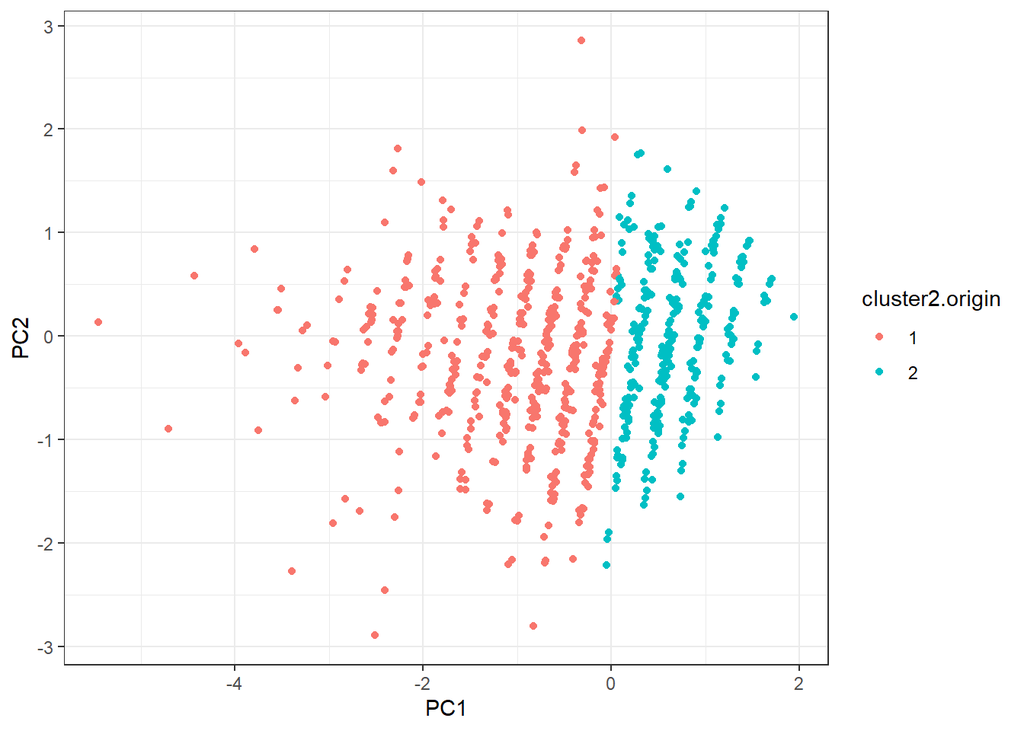

```r
esteem.pcscore = data.table(pca.esteem$x,cluster2.origin = as.factor(esteem.cluster2.origin$cluster))

ggplot(data = esteem.pcscore,aes(x=PC1,y=PC2,group = cluster2.origin,color=cluster2.origin))+
  geom_point()+
  geom_jitter()+
  theme_bw()
```

### 1.2.5 Regression

**Prepare variables**

```r
pcscore.asvab = data.frame(prcomp(esteem[,16:26],scale. = T)$x) # should be scaled

esteem[,c("pc1.esteem87","pc1.asvab") := .(esteem.pcscore$PC1,pcscore.asvab$PC1)]

esteem[Income87==0,Income87 := 1] # deal with zeros

esteem.reg = esteem[,.(
  Gender,
  Education05,
  log.Income87 = log(Income87),
  Job05, # no job87
  Bmi05 = Weight05/2.20462262/((HeightFeet05+HeightInch05/12)/3.2808399)^2,
  Imagazine = as.factor(Imagazine),
  Ilibrary = as.factor(Ilibrary),
  MotherEd,
  FatherEd,
  FamilyIncome78,
  pc1.asvab,
  pc1.esteem87
)]

job.list = unique(esteem.reg[,Job05])
job.code = data.table(job05.list = job.list, Job05code = as.factor(1:length(job.list)))
esteem.reg = esteem.reg %>%
  left_join(job.code,c("Job05" = "job05.list"))
esteem.reg[,Job05 := NULL]
```

**Full regression**

```r
# full regression
esteem.fullreg = lm(pc1.esteem87~.,data = esteem.reg)
summary(esteem.fullreg)
```

```
##
## Call:
## lm(formula = pc1.esteem87 ~ ., data = esteem.reg)
##
## Residuals:
##    Min     1Q Median     3Q    Max
## -4.988 -0.920 -0.037  0.998  3.008
##
## Coefficients:
##                 Estimate Std. Error t value Pr(>|t|)
## (Intercept)    -1.08e+00   2.82e-01   -3.85  0.00012 ***
## Gendermale      1.29e-01   6.15e-02    2.09  0.03649 *
## Education05     4.93e-02   1.42e-02    3.47  0.00053 ***
## log.Income87    2.31e-02   8.37e-03    2.76  0.00575 **
## Bmi05          -5.11e-03   4.41e-03   -1.16  0.24662
## Imagazine1      1.51e-03   6.23e-02    0.02  0.98067
## Ilibrary1       8.23e-02   6.31e-02    1.31  0.19202
## MotherEd        1.52e-02   1.30e-02    1.17  0.24310
## FatherEd        1.74e-03   9.66e-03    0.18  0.85681
## FamilyIncome78  1.87e-06   2.01e-06    0.93  0.35110
## pc1.asvab       6.88e-02   1.30e-02    5.31  1.2e-07 ***
## Job05code2      1.85e-01   1.07e-01    1.72  0.08539 .
## Job05code3     -7.64e-02   1.47e-01   -0.52  0.60340
## Job05code4      5.86e-02   1.10e-01    0.54  0.59237
## Job05code5     -4.17e-01   1.76e-01   -2.37  0.01800 *
## Job05code6     -2.20e-01   1.41e-01   -1.55  0.12049
## Job05code7     -3.17e-01   1.92e-01   -1.65  0.09910 .
## Job05code8     -4.40e-01   5.07e-01   -0.87  0.38568
## Job05code9     -1.26e-01   1.48e-01   -0.85  0.39720
## Job05code10     1.95e-01   1.71e-01    1.14  0.25606
## Job05code11     1.51e-01   1.77e-01    0.85  0.39445
## Job05code12    -4.27e-01   1.52e-01   -2.80  0.00514 **
## Job05code13     2.89e-01   1.47e-01    1.97  0.04918 *
## Job05code14     3.98e-02   2.09e-01    0.19  0.84879
## Job05code15    -5.05e-03   1.49e-01   -0.03  0.97302
## Job05code16     4.27e-02   3.50e-01    0.12  0.90302
## Job05code17    -5.77e-02   2.44e-01   -0.24  0.81296
## Job05code18     9.14e-03   3.29e-01    0.03  0.97785
## Job05code19    -3.30e-01   1.74e-01   -1.89  0.05825 .
## Job05code20     4.23e-01   1.88e-01    2.26  0.02412 *
## Job05code21    -3.10e-01   1.45e-01   -2.14  0.03227 *
## Job05code22    -8.48e-02   2.14e-01   -0.40  0.69253
## Job05code23    -5.17e-02   1.97e-01   -0.26  0.79311
## Job05code24    -5.59e-01   4.18e-01   -1.34  0.18136
## Job05code25     4.48e-01   2.64e-01    1.70  0.08971 .
## Job05code26    -6.22e-02   4.69e-01   -0.13  0.89457
## Job05code27    -9.20e-01   3.96e-01   -2.32  0.02031 *
## Job05code28    -1.24e+00   6.17e-01   -2.01  0.04426 *
## Job05code29    -1.22e-01   6.16e-01   -0.20  0.84330
## Job05code30    -4.07e-01   1.22e+00   -0.33  0.73916
## ---
## Signif. codes:  0 '***' 0.001 '**' 0.01 '*' 0.05 '.' 0.1 ' ' 1
##
## Residual standard error: 1.22 on 2306 degrees of freedom
## Multiple R-squared:  0.128,  Adjusted R-squared:  0.113
## F-statistic: 8.68 on 39 and 2306 DF,  p-value: <2e-16
```

```r
esteem.selectedreg1 = lm(pc1.esteem87~Education05+log.Income87+pc1.asvab+Job05code,data = esteem.reg)
summary(esteem.selectedreg1)
```

```
##
## Call:
## lm(formula = pc1.esteem87 ~ Education05 + log.Income87 + pc1.asvab +
##     Job05code, data = esteem.reg)
##
## Residuals:
##    Min     1Q Median     3Q    Max
## -4.837 -0.934 -0.035  0.997  3.072
##
## Coefficients:
##              Estimate Std. Error t value Pr(>|t|)
## (Intercept)  -0.99498    0.22146   -4.49  7.4e-06 ***
## Education05   0.05823    0.01385    4.20  2.7e-05 ***
## log.Income87  0.02581    0.00830    3.11   0.0019 **
## pc1.asvab     0.08214    0.01202    6.83  1.1e-11 ***
## Job05code2    0.18798    0.10714    1.75   0.0795 .
## Job05code3   -0.05627    0.14602   -0.39   0.7000
## Job05code4    0.01163    0.10755    0.11   0.9139
## Job05code5   -0.41239    0.17549   -2.35   0.0189 *
## Job05code6   -0.17457    0.13849   -1.26   0.2076
## Job05code7   -0.30307    0.19194   -1.58   0.1145
## Job05code8   -0.45817    0.50692   -0.90   0.3662
## Job05code9   -0.08171    0.14625   -0.56   0.5764
## Job05code10   0.13167    0.16926    0.78   0.4367
## Job05code11   0.15215    0.17752    0.86   0.3915
## Job05code12  -0.48631    0.15048   -3.23   0.0012 **
## Job05code13   0.26601    0.14674    1.81   0.0700 .
## Job05code14   0.00051    0.20730    0.00   0.9980
## Job05code15  -0.04669    0.14799   -0.32   0.7524
## Job05code16   0.01479    0.34946    0.04   0.9662
## Job05code17  -0.11475    0.24235   -0.47   0.6359
## Job05code18   0.01519    0.32915    0.05   0.9632
## Job05code19  -0.33310    0.17361   -1.92   0.0551 .
## Job05code20   0.44117    0.18719    2.36   0.0185 *
## Job05code21  -0.29490    0.14311   -2.06   0.0394 *
## Job05code22  -0.13231    0.21335   -0.62   0.5352
## Job05code23  -0.04375    0.19628   -0.22   0.8237
## Job05code24  -0.53716    0.41637   -1.29   0.1971
## Job05code25   0.44953    0.26398    1.70   0.0887 .
## Job05code26  -0.12583    0.46920   -0.27   0.7886
## Job05code27  -0.93414    0.39546   -2.36   0.0182 *
## Job05code28  -1.25635    0.61706   -2.04   0.0419 *
## Job05code29  -0.06338    0.61671   -0.10   0.9182
## Job05code30  -0.32644    1.22330   -0.27   0.7896
## ---
## Signif. codes:  0 '***' 0.001 '**' 0.01 '*' 0.05 '.' 0.1 ' ' 1
##
## Residual standard error: 1.22 on 2313 degrees of freedom
## Multiple R-squared:  0.124,  Adjusted R-squared:  0.111
## F-statistic: 10.2 on 32 and 2313 DF,  p-value: <2e-16
```

**Model diagnosis**

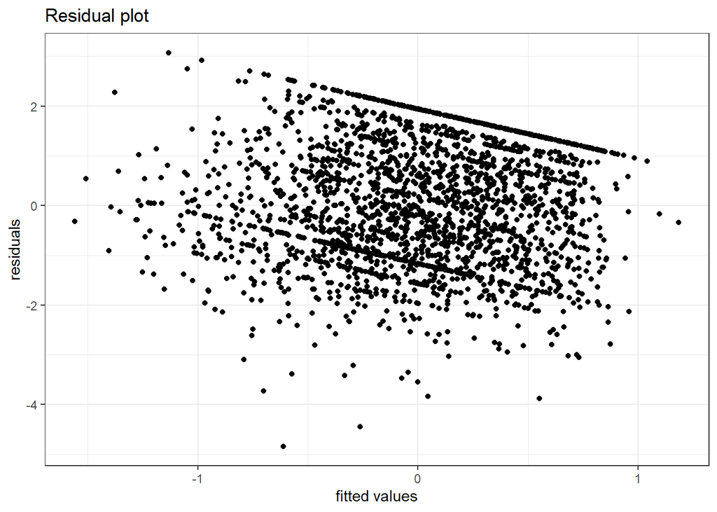

```r
# homoscedasticity of error
ggplot()+
  geom_point(aes(x=esteem.selectedreg1$fitted.values,y=esteem.selectedreg1$residuals))+
  xlab("fitted values")+
  ylab("residuals")+
  labs(title = "Residual plot")+
  theme_bw()
```

There is no clear trend for error. Homoscedasticity is roughly met.

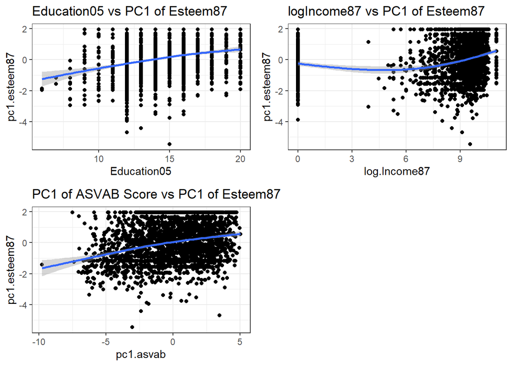

```r
# linearity
plot.edu.esteem = ggplot(data = esteem.reg,aes(x=Education05,y=pc1.esteem87))+
  geom_point()+
  geom_smooth()+
  labs(title = "Education05 vs PC1 of Esteem87")+
  theme_bw()
plot.income.esteem = ggplot(data = esteem.reg,aes(x=log.Income87,y=pc1.esteem87))+
  geom_point()+
  geom_smooth()+
  labs(title = "logIncome87 vs PC1 of Esteem87")+
  theme_bw()
plot.asvab.esteem = ggplot(data = esteem.reg,aes(x=pc1.asvab,y=pc1.esteem87))+
  geom_point()+
  geom_smooth()+
  labs(title = "PC1 of ASVAB Score vs PC1 of Esteem87")+
  theme_bw()

plot_grid(plot.edu.esteem,plot.income.esteem,plot.asvab.esteem)
```

According to the scatter plots presented above, the linearity assumption is roughly met. Note that the prevalence of zero in Income87 makes taking log no longer the most desirable choice. Using the original value instead may be better.

```r
esteem.reg[,Income87 := exp(log.Income87)]
esteem.reg[Income87 == 1, Income87 := 0]

esteem.selectedreg1.new = lm(pc1.esteem87~Education05+Income87+pc1.asvab+Job05code,data = esteem.reg)
summary(esteem.selectedreg1.new)
```

```
##
## Call:
## lm(formula = pc1.esteem87 ~ Education05 + Income87 + pc1.asvab +
##     Job05code, data = esteem.reg)
##
## Residuals:
##    Min     1Q Median     3Q    Max
## -4.866 -0.932 -0.039  0.973  3.097
##
## Coefficients:
##              Estimate Std. Error t value Pr(>|t|)
## (Intercept) -9.79e-01   2.12e-01   -4.61  4.3e-06 ***
## Education05  5.97e-02   1.38e-02    4.32  1.6e-05 ***
## Income87     1.21e-05   2.34e-06    5.19  2.3e-07 ***
## pc1.asvab    7.31e-02   1.22e-02    6.01  2.2e-09 ***
## Job05code2   1.67e-01   1.07e-01    1.56    0.119
## Job05code3  -5.53e-02   1.45e-01   -0.38    0.704
## Job05code4   5.00e-02   1.07e-01    0.47    0.642
## Job05code5  -3.91e-01   1.75e-01   -2.24    0.025 *
## Job05code6  -1.83e-01   1.38e-01   -1.33    0.184
## Job05code7  -2.94e-01   1.91e-01   -1.53    0.125
## Job05code8  -4.81e-01   5.05e-01   -0.95    0.341
## Job05code9  -8.80e-02   1.46e-01   -0.60    0.546
## Job05code10  1.49e-01   1.69e-01    0.88    0.377
## Job05code11  1.60e-01   1.77e-01    0.90    0.366
## Job05code12 -4.46e-01   1.50e-01   -2.97    0.003 **
## Job05code13  2.86e-01   1.46e-01    1.96    0.051 .
## Job05code14  1.91e-02   2.07e-01    0.09    0.927
## Job05code15 -5.76e-03   1.48e-01   -0.04    0.969
## Job05code16  1.10e-02   3.48e-01    0.03    0.975
## Job05code17 -6.25e-02   2.42e-01   -0.26    0.796
## Job05code18  3.58e-02   3.28e-01    0.11    0.913
## Job05code19 -3.02e-01   1.73e-01   -1.74    0.081 .
## Job05code20  4.54e-01   1.86e-01    2.43    0.015 *
## Job05code21 -2.90e-01   1.43e-01   -2.04    0.042 *
## Job05code22 -8.55e-02   2.13e-01   -0.40    0.688
## Job05code23 -4.29e-02   1.96e-01   -0.22    0.826
## Job05code24 -4.83e-01   4.15e-01   -1.16    0.245
## Job05code25  4.81e-01   2.63e-01    1.83    0.068 .
## Job05code26 -1.02e-01   4.67e-01   -0.22    0.827
## Job05code27 -9.07e-01   3.94e-01   -2.30    0.021 *
## Job05code28 -1.21e+00   6.15e-01   -1.96    0.050 *
## Job05code29 -8.58e-02   6.14e-01   -0.14    0.889
## Job05code30 -2.84e-01   1.22e+00   -0.23    0.816
## ---
## Signif. codes:  0 '***' 0.001 '**' 0.01 '*' 0.05 '.' 0.1 ' ' 1
##
## Residual standard error: 1.22 on 2313 degrees of freedom
## Multiple R-squared:  0.13,   Adjusted R-squared:  0.118
## F-statistic: 10.8 on 32 and 2313 DF,  p-value: <2e-16
```

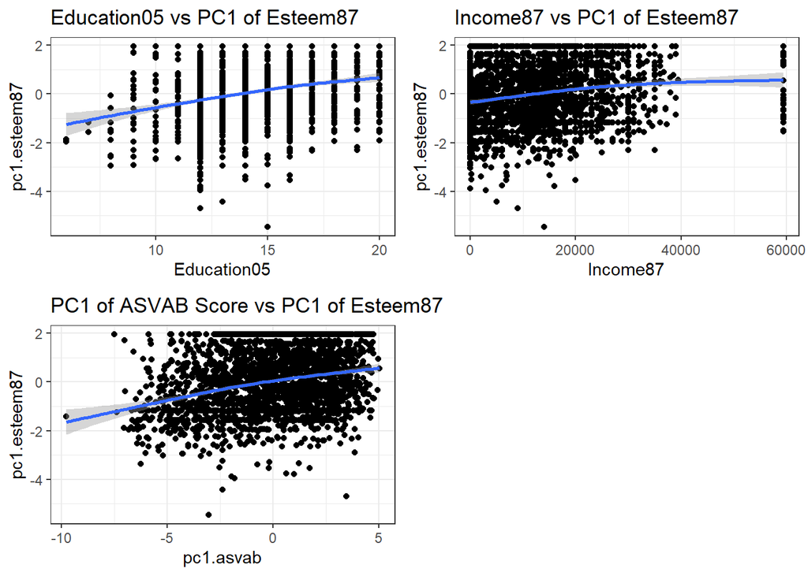

```r
plot.edu.esteem.new = ggplot(data = esteem.reg,aes(x=Education05,y=pc1.esteem87))+
  geom_point()+
  geom_smooth()+
  labs(title = "Education05 vs PC1 of Esteem87")+
  theme_bw()
plot.income.esteem.new = ggplot(data = esteem.reg,aes(x=Income87,y=pc1.esteem87))+
  geom_point()+
  geom_smooth()+
  labs(title = "Income87 vs PC1 of Esteem87")+
  theme_bw()
plot.asvab.esteem.new = ggplot(data = esteem.reg,aes(x=pc1.asvab,y=pc1.esteem87))+
  geom_point()+
  geom_smooth()+
  labs(title = "PC1 of ASVAB Score vs PC1 of Esteem87")+
  theme_bw()

plot_grid(plot.edu.esteem.new,plot.income.esteem.new,plot.asvab.esteem.new)
```

The relationship between Income87 and Esteem seems to be more linear if we use the original scale of Income87.

**Summary**

We find that Education level in 2005, Income in 1987, PC1 of ASVAB test in 1981 and Job type in 2005 are significantly predictive to the overall self esteem measured in 1987. The predictive power of the two variables measured in 2005 cannot be interpreted as causal relationship; instead, we can regard them as having a common determinant with Esteem87 (the common cause can be the corresponding measure in 1987, because one’s previous education should be positively correlated with current education, given that the person was an adult back then; so do jobs).

Education level, Income and ASVAB test score are all positively correlated with self esteem. These are reasonable because they are all signals that show you are “better” than others in a certain field. Also, advantages in these aspects can be converted into wealth, which should be positively correlated with one’s life quality (at least materially).

Job types also significantly correlated with self esteem. Compared to Sales and Related Workers, people working as Cleaning and Building Service Workers, Health Care Technical and Support Workers, Transportation and Material Moving Workers, Entertainment Attendants and Related Workers, Physical Scientists (suspicious as there are only four observations) have significantly less self esteem, possibly because these occupations are representative for low social status (except the last one). Protective Service Workers have more self esteem, possibly because they are physically much stronger; Management Related Workers have more self esteem, which may be attributed to their relatively high social status.

# 2 Case Study 2: Breast cancer sub-type

```r
cancer = fread("data/brca_subtype.csv")
patient = fread("data/brca_x_patient.csv")
```

## 2.1 Summary and transformation

**Number of patients in each subtype**

```r
cancer[,.(number = length(A1BG)),by = BRCA_Subtype_PAM50]
```

```
##    BRCA_Subtype_PAM50 number
## 1:               LumA    628
## 2:               Her2     91
## 3:               LumB    233
## 4:              Basal    208
```

**Histogram by subtype**

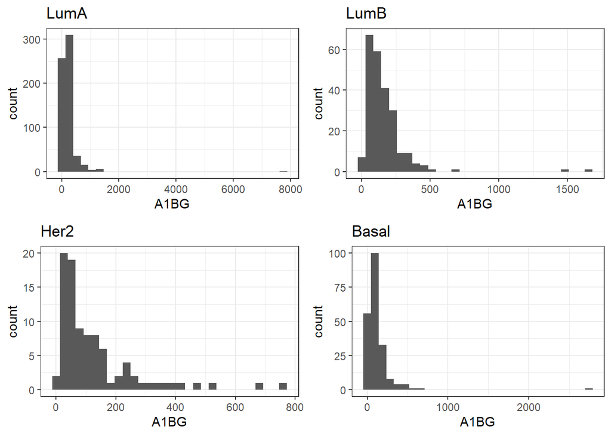

```r
hist.bysubtype = function(gene){
  luma = ggplot(data = cancer[BRCA_Subtype_PAM50 == "LumA"])+
    geom_histogram(aes(x=eval(parse(text = gene))))+
    xlab(gene)+
    labs(title = "LumA")+
    theme_bw()
  lumb = ggplot(data = cancer[BRCA_Subtype_PAM50 == "LumB"])+
    geom_histogram(aes(x=eval(parse(text = gene))))+
    xlab(gene)+
    labs(title = "LumB")+
    theme_bw()
  her2 = ggplot(data = cancer[BRCA_Subtype_PAM50 == "Her2"])+
    geom_histogram(aes(x=eval(parse(text = gene))))+
    xlab(gene)+
    labs(title = "Her2")+
    theme_bw()
  basal = ggplot(data = cancer[BRCA_Subtype_PAM50 == "Basal"])+
    geom_histogram(aes(x=eval(parse(text = gene))))+
    xlab(gene)+
    labs(title = "Basal")+
    theme_bw()
  plot_grid(luma,lumb,her2,basal,nrow = 2)
}

hist.bysubtype("A1BG")
```

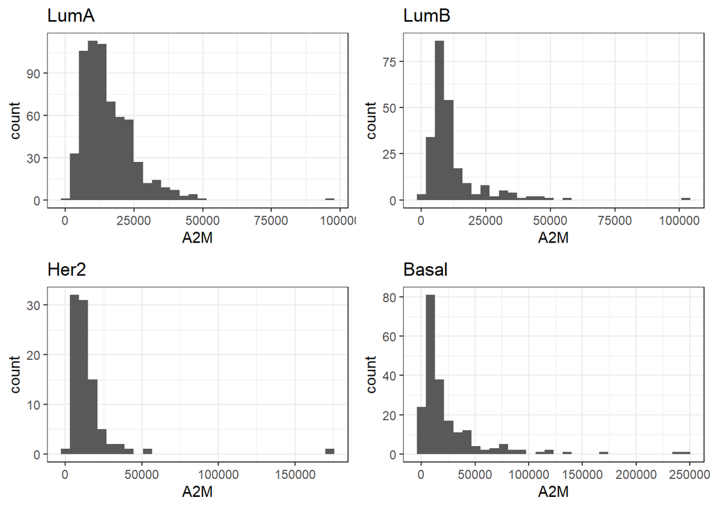

```r
hist.bysubtype("A2M")
```

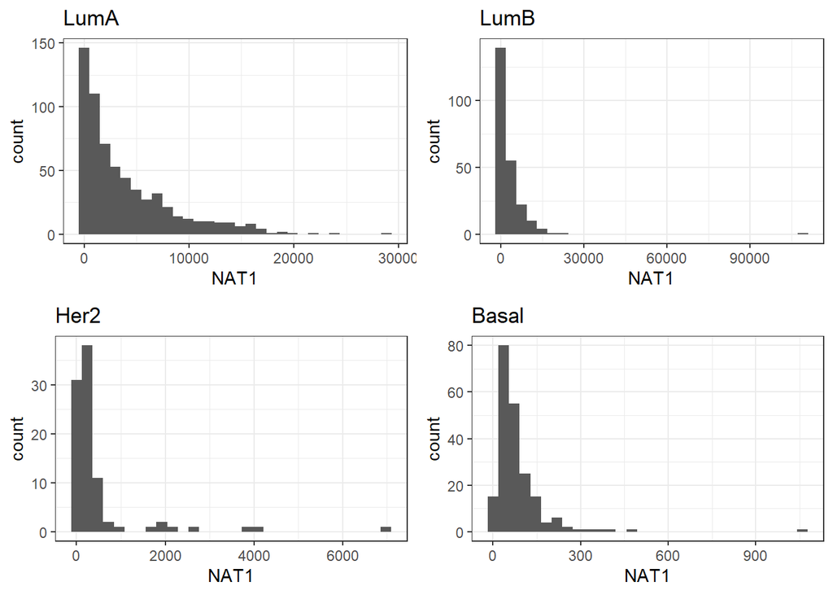

```r
hist.bysubtype("NAT1")
```

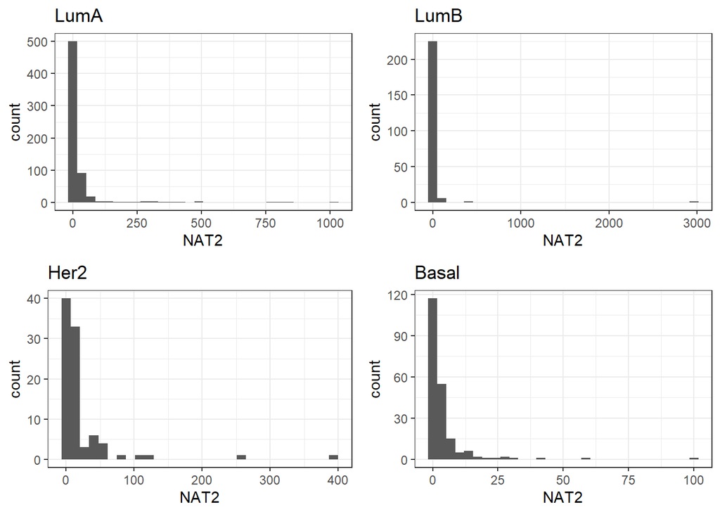

```r
hist.bysubtype("NAT2")
```

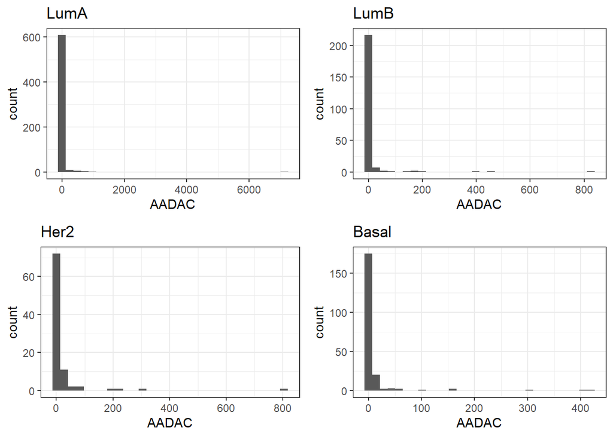

```r
hist.bysubtype("AADAC")
```

All the distributions are right-skewed. Outliers are prevalent.

**Transformation**

```r
# check NA
notna = !is.na(cancer)
notna.vec = apply(notna, 2, sum)
which(notna.vec==0)
```

```
## named integer(0)
```

```r
# check NULL
isnull.firstrow = sapply(cancer[1],is.null)
which(isnull.firstrow == T)
```

```
## named integer(0)
```

```r
# check variability
var = apply(cancer,2,var)
remove.col = which(var==0)
save(remove.col,file = "removecol.RData")
```

```r
load("removecol.RData") # if not saved, too slow to run
```

**Number of genes removed**

```r
length(remove.col)
```

```
## [1] 278
```

A total of 278 genes needs to be removed due to zero variability.

```r
# remove

cancer[,(names(remove.col)) := NULL]

# deal with zeros before transforming

get.minpositive = function(vec){
  min(vec[which(vec>0)])
}
min.positiveexp = apply(cancer[,-1], 2, get.minpositive)
```

```r
for (i in 2:ncol(cancer)) {
  cancer[get(colnames(cancer)[i])==0,colnames(cancer)[i] := min.positiveexp[i-1]/2, with = F]
}
save(cancer,file = "cancer.RData")
```

```r
load("cancer.RData")
```

```r
# transforming
log.cancer = cancer[,1] %>%
  cbind(log(cancer[,-1]))
```

## 2.2 kmeans clustering

```r
set.seed(1)
kmeans.cancer = kmeans(log.cancer[,-1],centers = 4)
table(log.cancer$BRCA_Subtype_PAM50,kmeans.cancer$cluster)
```

```
##
##           1   2   3   4
##   Basal   0  17   1 190
##   Her2   27   9  40  15
##   LumA  198  70 360   0
##   LumB  168  22  41   2
```

Kmeans clustering only separate Basal with others.

## 2.3 Spectrum clustering

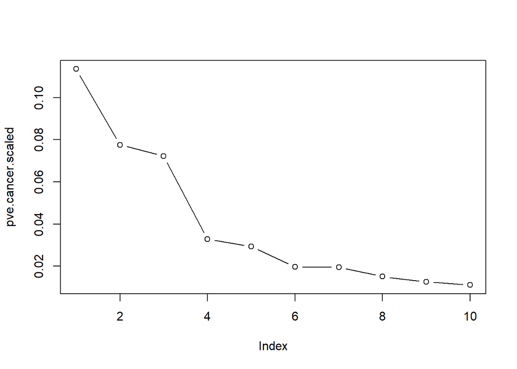

```r
log.cancer.scaled.centered = scale(log.cancer[,-1],center = T,scale = T)
svd.cancer.scaled = irlba(log.cancer.scaled.centered,nv = 10)

var.estimate.scaled = svd.cancer.scaled$d^2/(nrow(log.cancer.scaled.centered)-1)
pve.cancer.scaled = var.estimate.scaled/ncol(log.cancer.scaled.centered)
plot(pve.cancer.scaled,type = "b")
```

According to the elbow rule, we can use 3 PCs, as PVE decreases dramatically since PC4.

**Comparison of scaling choices**

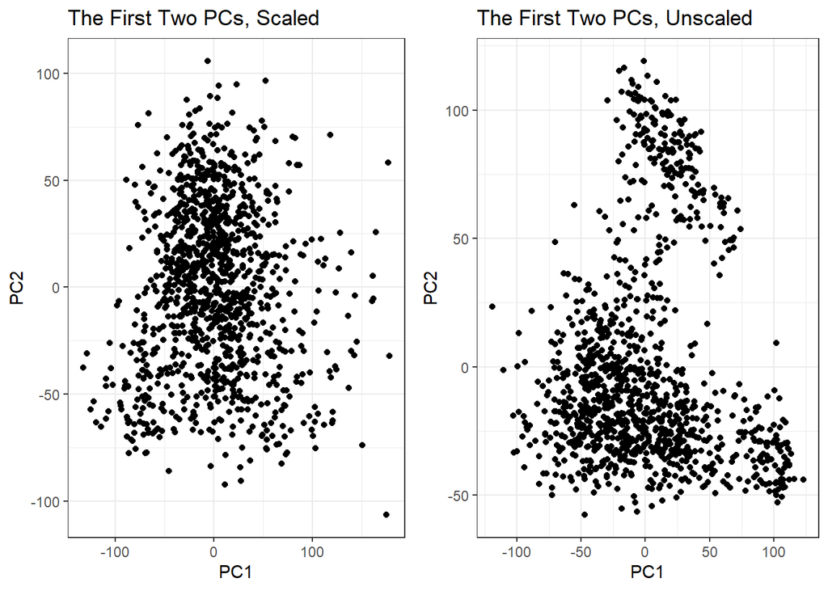

```r
pc.firsttwo.scaled = data.table(log.cancer.scaled.centered %*% svd.cancer.scaled$v[,1:2])
setnames(pc.firsttwo.scaled,c("PC1","PC2"))

log.cancer.unscaled.centered = scale(log.cancer[,-1],center = T,scale = F)
svd.cancer.unscaled = irlba(log.cancer.unscaled.centered,nv = 10)
pc.firsttwo.unscaled = data.table(log.cancer.unscaled.centered %*% svd.cancer.unscaled$v[,1:2])
setnames(pc.firsttwo.unscaled,c("PC1","PC2"))

pc.scatter.scaled = ggplot(data = pc.firsttwo.scaled,aes(x=PC1,y=PC2))+
  geom_point()+
  labs(title = "The First Two PCs, Scaled")+
  theme_bw()

pc.scatter.unscaled = ggplot(data = pc.firsttwo.unscaled,aes(x=PC1,y=PC2))+
  geom_point()+
  labs(title = "The First Two PCs, Unscaled")+
  theme_bw()

plot_grid(pc.scatter.scaled,pc.scatter.unscaled)
```

We should not scale the original data, since two clusters are obvious in the unscaled scatter plot. Intuitively we should not scale the variables, because scaling means that we assign equal weight for relative variability in every gene. This is generally not innocuous because some important genes may vary more, as they indicate the difference well; others vary a little and are not informative, thus we should not assign much weight on them by scaling.

## 2.4 Spectrum clustering, cont’d

**Optimal number of clusters**

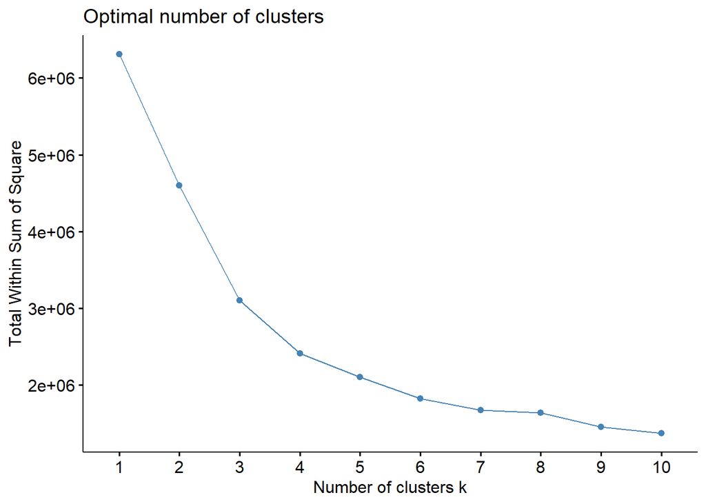

```r
pc.firstfour.unscaled = data.table(log.cancer.unscaled.centered %*% svd.cancer.unscaled$v[,1:4])
setnames(pc.firstfour.unscaled,c("PC1","PC2","PC3","PC4"))
fviz_nbclust(pc.firstfour.unscaled,kmeans,method = "wss")
```

We decide to choose $k=4$. On the one hand, The total WSS is no longer decreasing dramatically after $k=4$; on the other hand, this best conforms to our prior knowledge.

**Comparison between true groups and clusters**

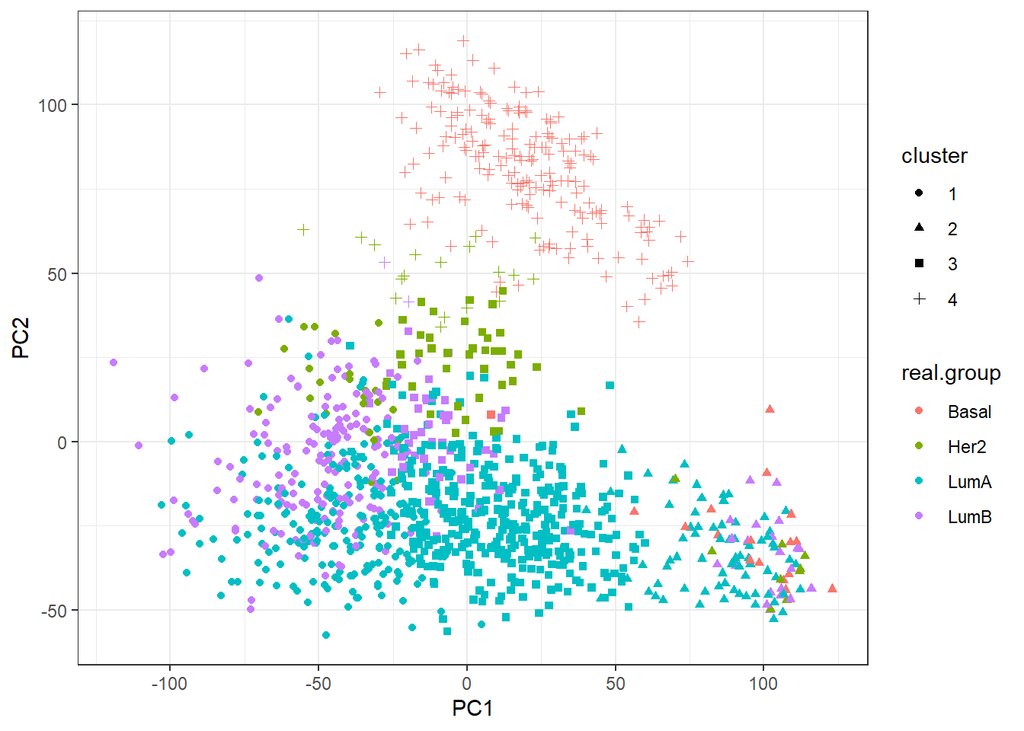

```r
set.seed(1) # otherwise the result varies
kmeans.cancer.4pc = kmeans(pc.firstfour.unscaled,centers = 4)
cancer.groupcomp = data.table(log.cancer[,1],pc.firstfour.unscaled,cluster = as.factor(kmeans.cancer.4pc$cluster))
setnames(cancer.groupcomp,1,"real.group")

ggplot(data = cancer.groupcomp,aes(x=PC1,y=PC2,color=real.group,pch=cluster))+
  geom_point()+
  theme_bw()
```

Overall, the clustering result is not bad. Basal is identified more clearly; Her2 is almost unidentified at all. The clustering is not perfect but acceptable.

**Comparison of clustering with original data and PCs**

```r
# original
kbl(table(log.cancer$BRCA_Subtype_PAM50,kmeans.cancer$cluster), caption = "Discrepancy Table, Original", digits = 2, booktabs = T,align = "lcccc") %>%
  kable_styling(latex_options = c("HOLD_position"))
```

Discrepancy Table, Original

|  | 1 | 2 | 3 | 4 |
| --- | --- | --- | --- | --- |
| Basal | 0 | 17 | 1 | 190 |
| Her2 | 27 | 9 | 40 | 15 |
| LumA | 198 | 70 | 360 | 0 |
| LumB | 168 | 22 | 41 | 2 |

```r
# PC
kbl(table(log.cancer$BRCA_Subtype_PAM50,kmeans.cancer.4pc$cluster), caption = "Discrepancy Table, 4PC", digits = 2, booktabs = T,align = "lcccc") %>%
  kable_styling(latex_options = c("HOLD_position"))
```

Discrepancy Table, 4PC

|  | 1 | 2 | 3 | 4 |
| --- | --- | --- | --- | --- |
| Basal | 0 | 17 | 1 | 190 |
| Her2 | 24 | 9 | 40 | 18 |
| LumA | 205 | 73 | 350 | 0 |
| LumB | 165 | 22 | 44 | 2 |

Judging from the discrepancy tables, PCA seldom helps in kmeans clustering. In theory PCA just makes the information more intensive; if we are using all information with the original data in kmeans, its performance should not be much worse than that using only a few PCs with partial information. If it is the case that PCA does help, it may be attributed to the exclusion of noise.

**Classification of a new patient**

```r
patient[,(names(remove.col)) := NULL]

# deal with zeros
for (i in 1:ncol(patient)) {
  patient[get(colnames(patient)[i])==0,colnames(patient)[i] := min.positiveexp[i]/2, with = F]
}
save(patient,file = "patient.RData")
```

```r
load("patient.RData")
```

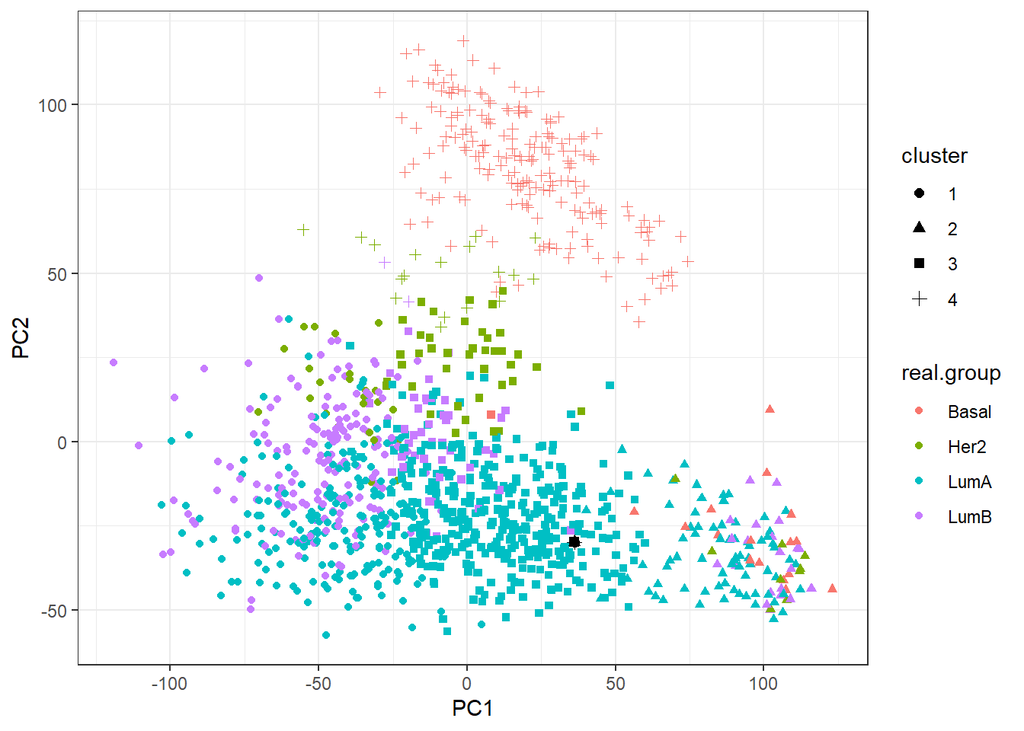

```r
# transforming
log.patient = log(patient)

# centering
log.patient = log.patient - apply(log.cancer[,-1],2,mean)

patient.firsttwo.unscaled = data.table(as.matrix(log.patient) %*% svd.cancer.scaled$v[,1:2])
patient.firsttwo.unscaled.mat = rbind(patient.firsttwo.unscaled,patient.firsttwo.unscaled,patient.firsttwo.unscaled,patient.firsttwo.unscaled)

ggplot(data = cancer.groupcomp,aes(x=PC1,y=PC2,color=real.group,pch=cluster))+
  geom_point()+
  geom_point(aes(x=patient.firsttwo.unscaled$V1,y=patient.firsttwo.unscaled$V2),color = "black",size=2)+
  theme_bw()
```

```r
distance = kmeans.cancer.4pc$centers[,1:2] - patient.firsttwo.unscaled.mat
distance.square = diag(as.matrix(distance) %*% t(as.matrix(distance)))

which.min(distance.square)
```

```
## [1] 3
```

The first two PC scores of the patient is closest to the center of cluster 3. According to the discrepancy table, most observations belong to LumA. Therefore, the patient is most possibly categorized into LumA group.

# 3 Case study 3: Auto data set

## 3.1 EDA

```r
## Explore the data
names(Auto)
```

```
## [1] "mpg"          "cylinders"    "displacement" "horsepower"   "weight"
## [6] "acceleration" "year"         "origin"       "name"
```

```r
skim(Auto)
```

Data summary

| Name | Auto |
| --- | --- |
| Number of rows | 392 |
| Number of columns | 9 |
| _______________________ |  |
| Column type frequency: |  |
| factor | 1 |
| numeric | 8 |
| ________________________ |  |
| Group variables | None |

**Variable type: factor**

| skim_variable | n_missing | complete_rate | ordered | n_unique | top_counts |
| --- | --- | --- | --- | --- | --- |
| name | 0 | 1 | FALSE | 301 | amc: 5, for: 5, toy: 5, amc: 4 |

**Variable type: numeric**

| skim_variable | n_missing | complete_rate | mean | sd | p0 | p25 | p50 | p75 | p100 | hist |
| --- | --- | --- | --- | --- | --- | --- | --- | --- | --- | --- |
| mpg | 0 | 1 | 23.45 | 7.81 | 9 | 17.0 | 22.8 | 29 | 46.6 | ▆▇▆▃▁ |
| cylinders | 0 | 1 | 5.47 | 1.71 | 3 | 4.0 | 4.0 | 8 | 8.0 | ▇▁▃▁▅ |
| displacement | 0 | 1 | 194.41 | 104.64 | 68 | 105.0 | 151.0 | 276 | 455.0 | ▇▂▂▃▁ |
| horsepower | 0 | 1 | 104.47 | 38.49 | 46 | 75.0 | 93.5 | 126 | 230.0 | ▆▇▃▁▁ |
| weight | 0 | 1 | 2977.58 | 849.40 | 1613 | 2225.2 | 2803.5 | 3615 | 5140.0 | ▇▇▅▅▂ |
| acceleration | 0 | 1 | 15.54 | 2.76 | 8 | 13.8 | 15.5 | 17 | 24.8 | ▁▆▇▂▁ |
| year | 0 | 1 | 75.98 | 3.68 | 70 | 73.0 | 76.0 | 79 | 82.0 | ▇▆▇▆▇ |
| origin | 0 | 1 | 1.58 | 0.81 | 1 | 1.0 | 1.0 | 2 | 3.0 | ▇▁▂▁▂ |

Everything seems to be fine: no missing values, names of variables are good. The class of each variable matches its nature.

```r
# panel.hist<-function(x,...)
# {
#   usr<-par("usr");on.exit(par(usr))
#   par(usr=c(usr[1:2],0,1.5))
#   h<-hist(x,plot=FALSE)
#   breaks<-h$breaks;nB<-length(breaks)
#   y<-h$counts;y<-y/max(y)
#   rect(breaks[-nB],0,breaks[-1],y,...)
# }
# pairs(subset(Auto,select = -name),panel=panel.smooth, diag.panel=panel.hist)
```

**Correlations**

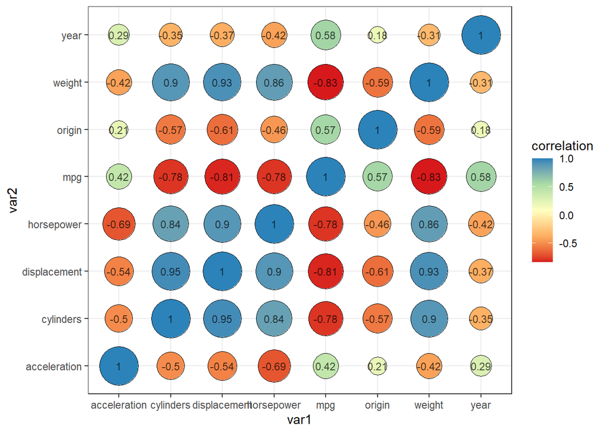

```r
Auto = data.table(Auto)
auto.corr.mat = data.frame(round(cor(Auto[,-"name"]), digits = 2),var1 = names(Auto)[-ncol(Auto)])
auto.corr.mat.long = data.table(melt(auto.corr.mat,id.vars = "var1", variable.name = "var2", value.name = "correlation"))
auto.corr.mat.long = auto.corr.mat.long[,var2 := as.character(var2)]
auto.corr.mat.long = auto.corr.mat.long[order(var1,var2)]

my_color = brewer.pal(5, "Spectral")
ggplot(data = auto.corr.mat.long,aes(x=var1,y=var2,fill = correlation))+
  geom_point(aes(size = abs(correlation)), shape = 21) +
  geom_text(aes(label = correlation), size = 3, colour = "black", alpha = 0.7)+
  scale_fill_gradientn(colours = my_color) +
  xlab("var1")+
  scale_size_area(max_size = 15, guide = "none") +
  theme_bw()
```

```r
Auto = data.frame(Auto)
```

Some explanatory variables are highly correlated. Thus we should pay attention to possible collinearity problems.

**Pairwise Scatter Plots**

```r
Auto.new = select(Auto, -name)
Auto.new = Auto.new %>%
  mutate(origin = as.factor(origin),cylinders = as.factor(cylinders))
```

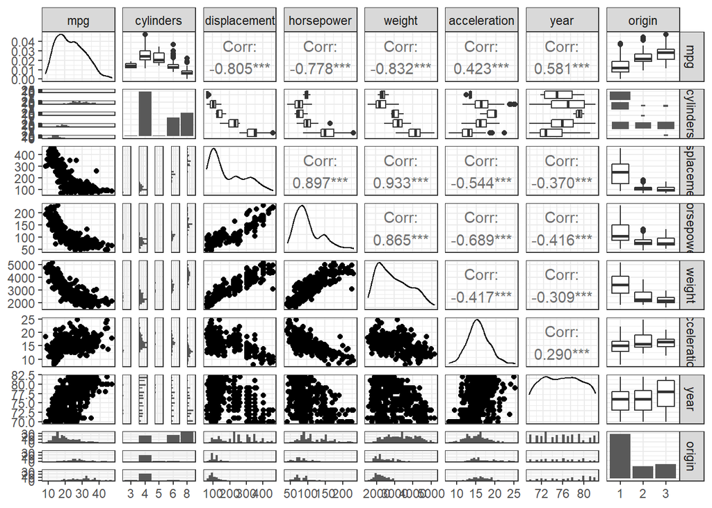

```r
ggpairs(Auto.new)+
  theme_bw()
```

From the pairwise scatter plots, we can see that:

The original mpg is right-skewed. Also it has a lower bound of zero in common sense. Therefore, we may want to use log(mpg) instead of mpg in the following analysis.

Alternatively, `Horsepower`, `displacement` and `weight` may need a transformation; the pairwise plot tells us that mpg may be linearly correlated to their reciprocals.

Next we will examine the effects of two alternative transformations.

```r
Auto.new1 = Auto.new %>%
  mutate(horsepower = 1/horsepower, displacement = 1/displacement, weight = 1/weight) %>%
  rename(c("horsepower" = "horsepower.rec", "displacement" = "displacement.rec", "weight" = "weight.rec"))
Auto.new2 = Auto.new %>%
  mutate(mpg = log(mpg)) %>%
  rename(c("mpg" = "log.mpg"))
```

**Transformation: displacement, horsepower and weight -> their reciprocals**

Here we have a closer look at the comparison between displacement, horsepower, weight and their reciprocals in terms of their relationship with mpg.

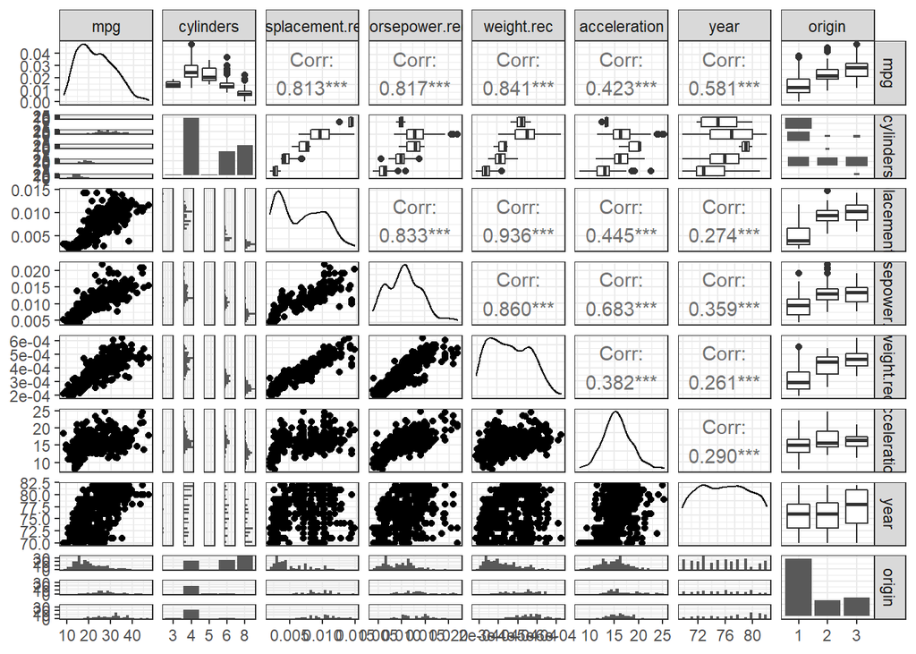

```r
ggpairs(Auto.new1)+
  theme_bw()
```

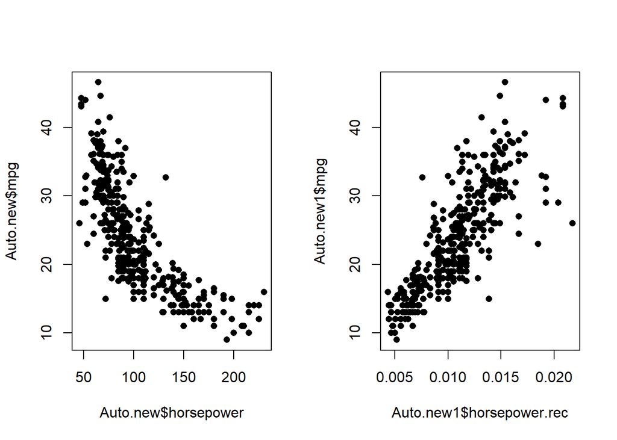

```r
par(mfrow=c(1,2))
plot(Auto.new$horsepower, Auto.new$mpg, pch=16)
plot(Auto.new1$horsepower.rec, Auto.new1$mpg, pch=16)  #looks better!
```

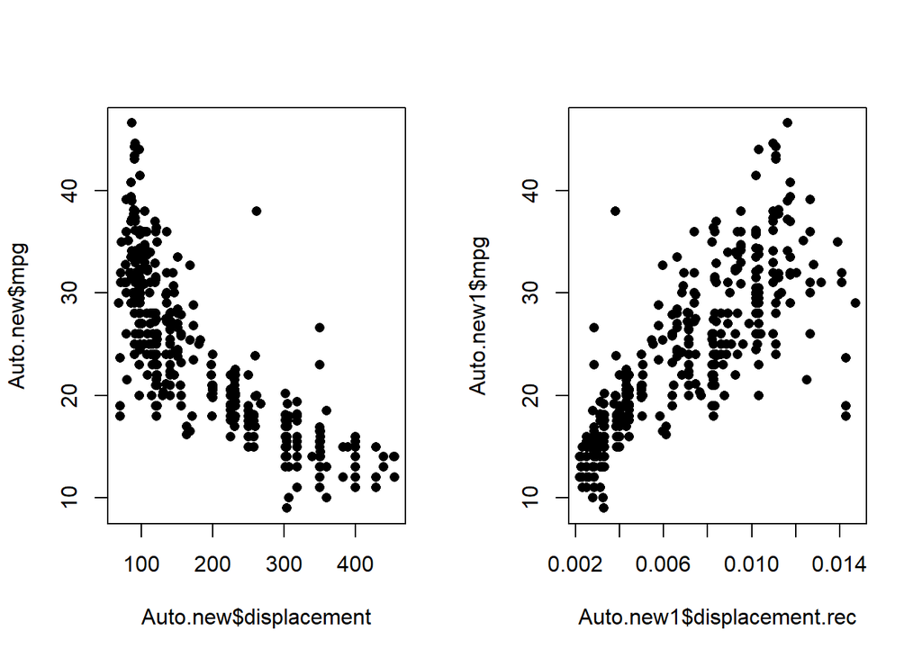

```r
par(mfrow=c(1,2))
plot(Auto.new$displacement, Auto.new$mpg, pch=16)
plot(Auto.new1$displacement.rec, Auto.new1$mpg, pch=16)  #looks better!
```

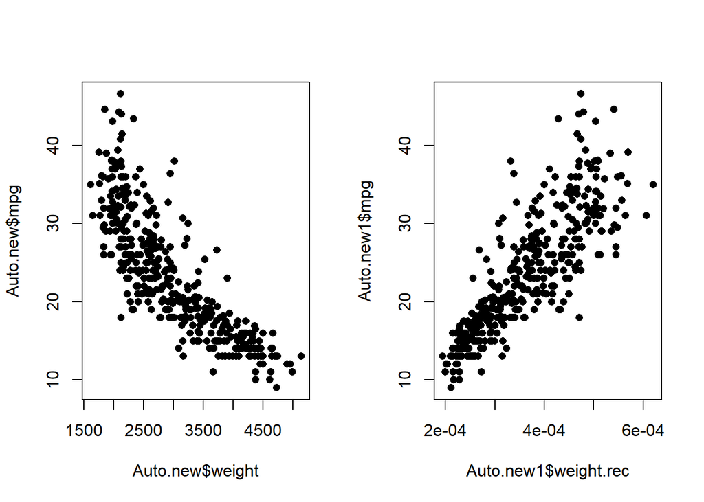

```r
par(mfrow=c(1,2))
plot(Auto.new$weight, Auto.new$mpg, pch=16)
plot(Auto.new1$weight.rec, Auto.new1$mpg, pch=16)  #looks better!
```

**Transformation: mpg -> log(mpg)**

Here we have a closer look at the comparison between mpg and log(mpg) in terms of their relationship with the three variables.

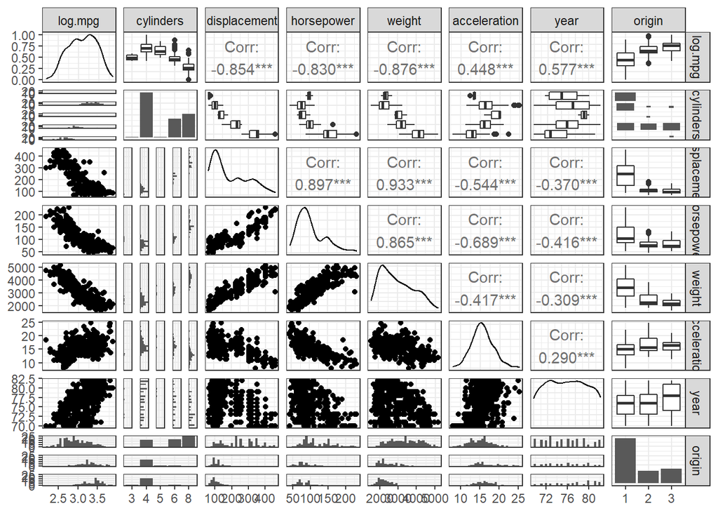

```r
ggpairs(Auto.new2)+
  theme_bw()
```

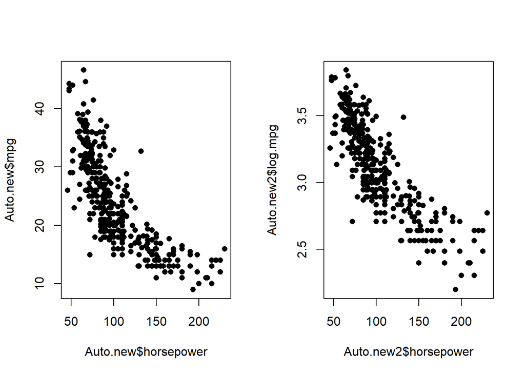

```r
par(mfrow=c(1,2))
plot(Auto.new$horsepower, Auto.new$mpg, pch=16)
plot(Auto.new2$horsepower, Auto.new2$log.mpg, pch=16)  #looks better!
```

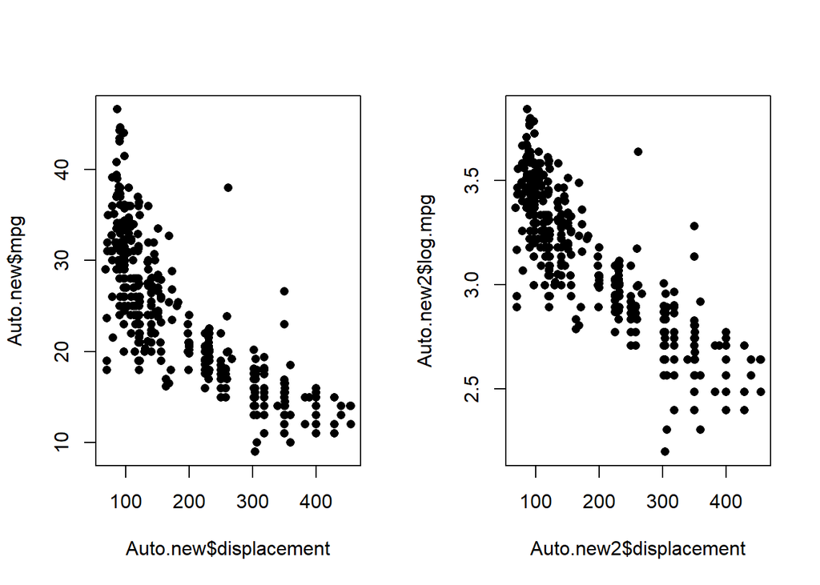

```r
par(mfrow=c(1,2))
plot(Auto.new$displacement, Auto.new$mpg, pch=16)
plot(Auto.new2$displacement, Auto.new2$log.mpg, pch=16)  #looks better!
```

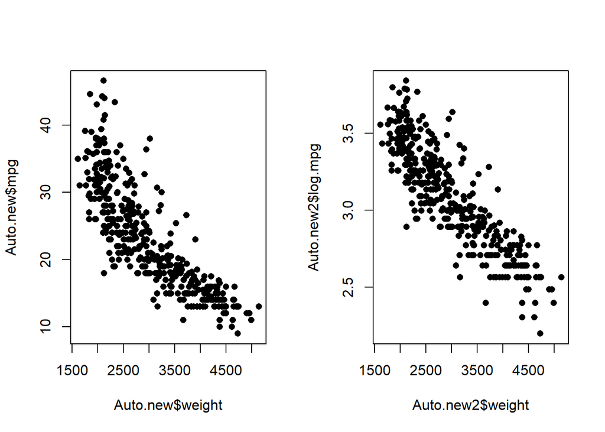

```r
par(mfrow=c(1,2))
plot(Auto.new$weight, Auto.new$mpg, pch=16)
plot(Auto.new2$weight, Auto.new2$log.mpg, pch=16)  #looks better!
```

## 3.2 What effect does `time` have on `MPG`?

### 3.2.1 Model 1: `MPG ~ Year`

We first do a simple regression. Let the response $y_i$ be the `MPG` and the explanatory variable $x_{i1}$ be `Year` ($i = 1, \dots, n=392$).

$$y_i = \beta_0 + \beta_1 \cdot x_{i1} + \epsilon$$

Model assumptions:

1. Linearity: given `Year`, the mean of `MPG` is described as $\textbf{E}(y_i | x_i) = \beta_0 + \beta_1 x_i$
2. Homoscedasticity: the variances of `MPG` are the same for any `Year` i.e. $\textbf{Var}(y_i | x_{i1}) = \sigma_{1}^2$
3. Normality: `MPG` is independent and normally distributed. i.e. $\epsilon_i \overset{iid}{\sim} \mathcal{N}(0, \sigma_{1}^2)$
4. Exogeneity: The error term is uncorrelated with the explanatory variables.
5. Non-collinearity: none of the explanatory variables are perfectly correlated.

We now create a model with `lm()`

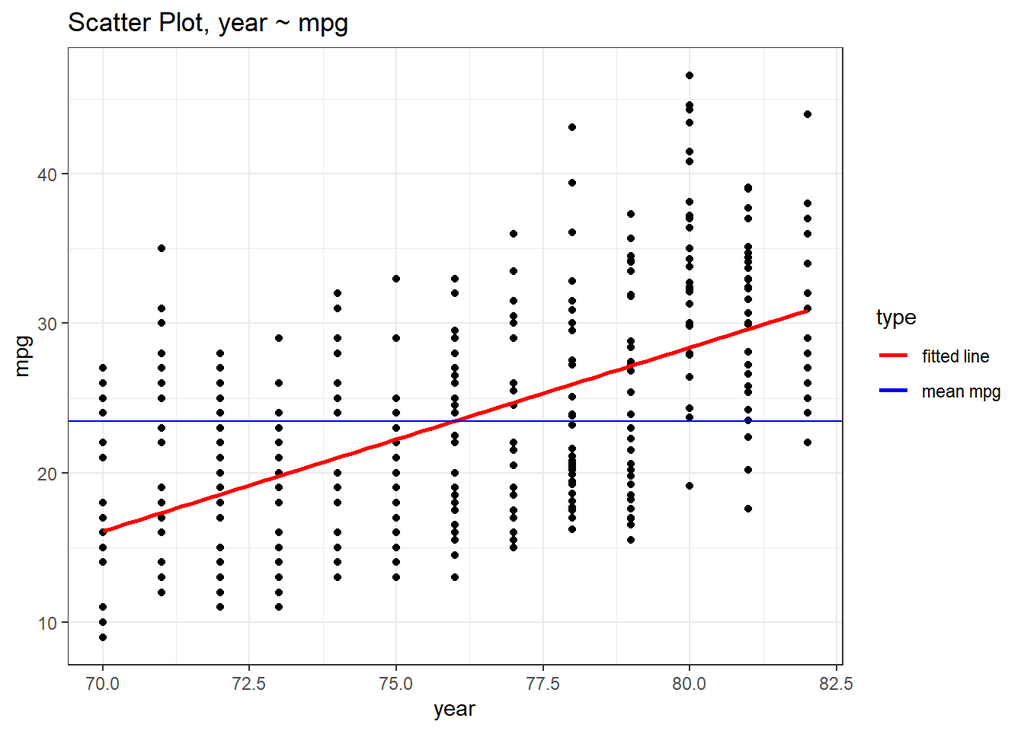

```r
fit1 <- lm(mpg ~ year, data = Auto)    # model specification response ~ x1,..
ggplot(Auto, aes(x = year , y = mpg)) +
  geom_point() +
  geom_smooth(aes(color = "fitted line"),method="lm",se=F) +
  geom_hline(aes(yintercept = mean(mpg), color = "mean mpg")) +
  scale_colour_manual(name = "type",values = c("red","blue"))+
  labs(title = "Scatter Plot, year ~ mpg") +
  theme_bw()
```

```r
stargazer::stargazer(fit1, type=output_format, align=TRUE)
```

|  | *Dependent variable:* |
| --- | --- |
|  | mpg |
| year | 1.230*** |
|  | (0.087) |
| Constant | -70.000*** |
|  | (6.640) |
| Observations | 392 |
| R<sup>2</sup> | 0.337 |
| Adjusted R<sup>2</sup> | 0.335 |
| Residual Std. Error | 6.360 (df = 390) |
| F Statistic | 198.000*** (df = 1; 390) |
| *Note:* | p<0.1; p<0.05; p<0.01 |

`Year` is a significant variable at the .05 level.

`Year` effect: When model year increases by 1 unit, we expect, on average the mpg will increase about 1.2300.

### 3.2.2 Model 2: `MPG ~ Year + Horsepower`

Let the response $y_i$ be the `MPG` and the explanatory variables be `Year` and `Horsepower` ($i = 1, \dots, n=392$).

$$y_i = \beta_0 + \beta_1 \cdot x_{i1} + \beta_2 \cdot x_{i2} + \epsilon$$

```r
fit2 <- lm(mpg ~ year + horsepower, data = Auto)
stargazer::stargazer(fit2, type=output_format, align=TRUE)
```

|  | *Dependent variable:* |
| --- | --- |
|  | mpg |
| year | 0.657*** |
|  | (0.066) |
| horsepower | -0.132*** |
|  | (0.006) |
| Constant | -12.700** |
|  | (5.350) |
| Observations | 392 |
| R<sup>2</sup> | 0.685 |
| Adjusted R<sup>2</sup> | 0.684 |
| Residual Std. Error | 4.390 (df = 389) |
| F Statistic | 424.000*** (df = 2; 389) |
| *Note:* | p<0.1; p<0.05; p<0.01 |

`Year` is still a significant variable at the .05 level.

`Year` effect: When model year increases by 1 unit, we expect, on average the mpg will increase about 0.657.